# Learning Plan

### Lesson 1-1: Introduction to RL

In this lesson, you'll explore a friendly introduction to reinforcement learning.

### Lesson 1-2: The RL Framework: The Problem

In this lesson, you'll learn how to specify a real-world problem as a Markov Decision Process (MDP), so that it can be solved with reinforcement learning.

### Lesson 1-3: The RL Framework: The Solution

In this lesson, you'll learn all about value functions and optimal policies.

### Lesson 1-4: Dynamic Programming (Optional)

In this lesson, you'll build some intuition for the reinforcement learning problem by learning about a class of solution methods that solve a slightly easier problem. (This lesson is optional and can be accessed in the extracurricular content.)

### Lesson 1-5: Monte Carlo Methods

In this lesson, you'll learn about a class of solution methods known as Monte Carlo methods. You'll implement your own Blackjack-playing agent in OpenAI Gym

### Lesson 1-6: Temporal-Difference Methods

In this lesson, you'll learn how to apply temporal-difference methods such as SARSA, Q-learning, and Expected SARSA to solve both episodic and continuing tasks.

### Lesson 1-7: Solve OpenAI Gym's Taxi-v2 Task

In this lesson, you'll apply what you've learned to train a taxi to pick up and drop off passengers.

### Lesson 1-8: RL in Continuous Spaces

In this lesson, you'll explore how to use techniques such as tile coding and coarse coding to expand the size of the problems that can be solved with traditional reinforcement learning algorithms.

# Reference

### Notation - cheatsheet

Notation - cheatsheet

```python
from IPython.display import IFrame
display(IFrame("../cheatsheet/cheatsheet.pdf", width=800, height=400))
```

[interactive chart not shown]

### Textbook

[Reinforcement Learning: An Introduction by Richard S. Sutton and Andrew G. Barto - Second Edition] http://incompleteideas.net/book/the-book.html

# Lesson 1-1: Introduction to RL

## 1-1-1 RL Framework : The Problem

### RL Framework Basic Concepts

- agent
- envirionment
- state
- action
- reward

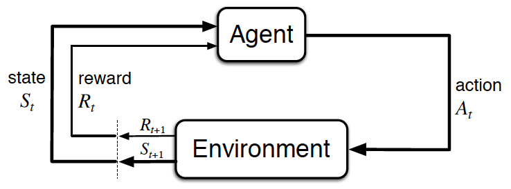

```python
from IPython.display import Image
Image(filename='./images/1-1-1-0_agent_environment_interaction_in_rl-Sutton_Barto_2017.png')
```

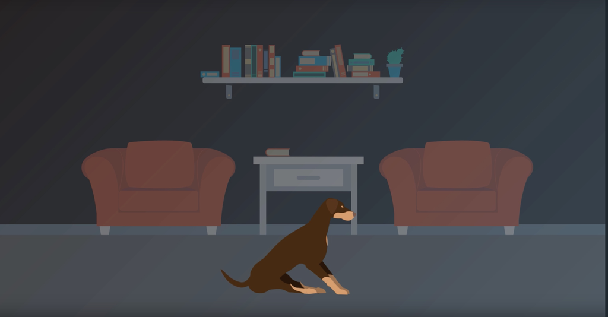

```python
from IPython.display import Image
Image(filename='./images/1-1-1-1_agent.jpeg')
```

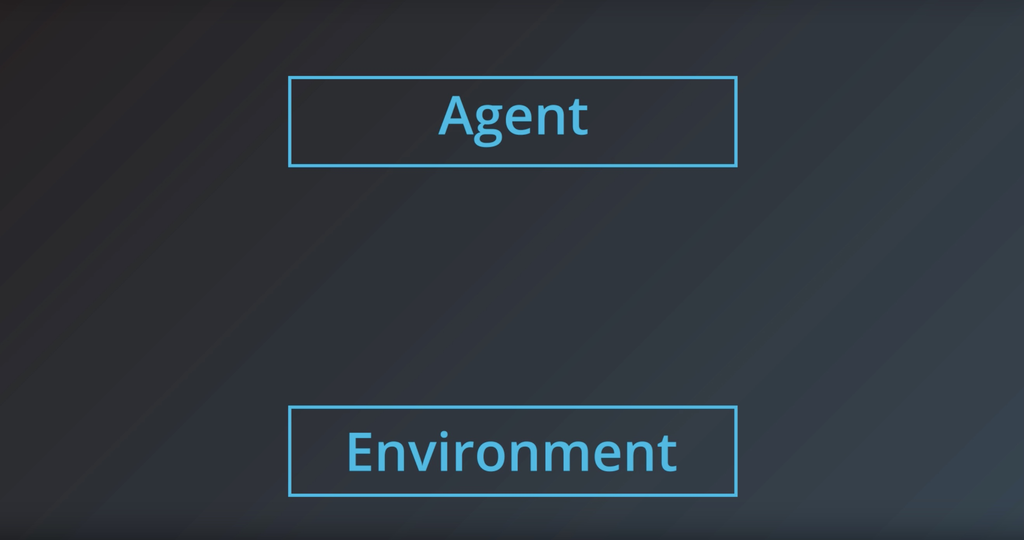

```python
from IPython.display import Image
Image(filename='./images/1-1-1-2_environment.jpeg')
```

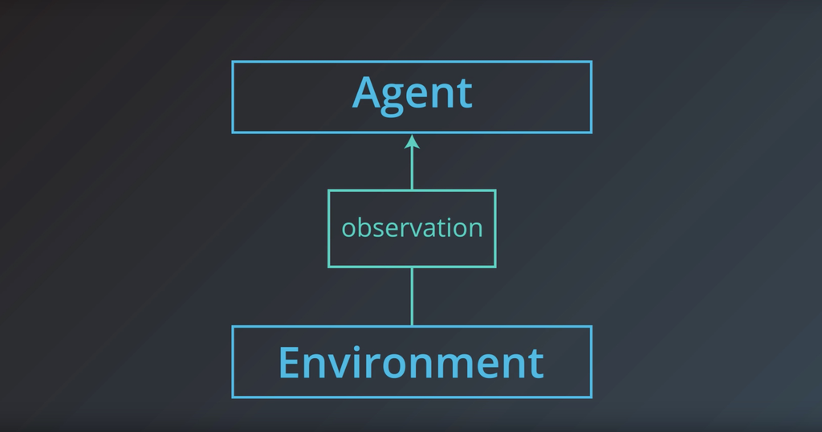

```python
from IPython.display import Image
Image(filename='./images/1-1-1-3_observation.jpeg')
```